# Linear Regression and Random Forest

Setup

```r
library(pacman)
pacman::p_load(tree, rpart, randomForest, ranger, rattle, pROC, partykit, ggplot2, glmnet,lda, data.table, ISLR, car, dplyr, tidyverse, stats, skimr)
```

## Data Preparation

Read in the Data

```r
names(data.full)
```

```
  [1] "country"                                        "cumulative_total_cases_prevac"                  "daily_new_cases_prevac"
  [4] "active_cases_prevac"                            "daily_new_cases_per_hundred_prevac"             "cumulative_total_cases_per_hundred_prevac"
  [7] "active_cases_per_hundred_prevac"                "monthly_new_cases_prevac"                       "monthly_new_cases_per_hundred_prevac"
 [10] "weekly_new_cases_prevac"                        "weekly_new_cases_per_hundred_prevac"            "cumulative_total_deaths_prevac"
 [13] "daily_new_deaths_prevac"                        "daily_new_deaths_per_hundred_prevac"            "cumulative_total_deaths_per_hundred_prevac"
 [16] "monthly_new_deaths_prevac"                      "monthly_new_deaths_per_hundred_prevac"          "weekly_new_deaths_prevac"
 [19] "weekly_new_deaths_per_hundred_prevac"           "cumulative_total_cases_1yr"                     "daily_new_cases_1yr"
 [22] "active_cases_1yr"                               "daily_new_cases_per_hundred_1yr"                "cumulative_total_cases_per_hundred_1yr"
 [25] "active_cases_per_hundred_1yr"                   "monthly_new_cases_1yr"                          "monthly_new_cases_per_hundred_1yr"
 [28] "weekly_new_cases_1yr"                           "weekly_new_cases_per_hundred_1yr"               "cumulative_total_deaths_1yr"
 [31] "daily_new_deaths_1yr"                           "daily_new_deaths_per_hundred_1yr"               "cumulative_total_deaths_per_hundred_1yr"
 [34] "monthly_new_deaths_1yr"                         "monthly_new_deaths_per_hundred_1yr"             "weekly_new_deaths_1yr"
 [37] "weekly_new_deaths_per_hundred_1yr"              "daily_new_cases_max"                            "daily_new_deaths_max"
 [40] "daily.new.cases.per.100_max"                    "daily.new.deaths.per.100_max"                   "monthly_new_cases_max"
 [43] "monthly_new_deaths_max"                         "monthly.new.cases.per.100_max"                  "monthly.new.deaths.per.100_max"
```

[output cut: 53 more lines]

merge with vaccination success index

```r
skim(data.full)
```

```
── Data Summary ────────────────────────
                           Values
Name                       data.full
Number of rows             108
Number of columns          207
_______________________
Column type frequency:
  character                13
  numeric                  194
________________________
Group variables            None

── Variable type: character ────────────────────────────────────────────────────────────────────────────────────────────────────────────────────────────────────────────────────────
   skim_variable             n_missing complete_rate   min   max empty n_unique whitespace
 1 country                           0         1         4    24     0      108          0
```

[output cut: 209 more lines]

We’ll remove the variables that have a high missing rate, and then remove the countries that have NAs below that threshold

```r
data.90 <- data.full[, apply(data.full, 2, function(col)sum(is.na(col))/length(col)) < 0.10]
data.complete <- na.omit(data.90)
nrow(data.complete)
```

```
[1] 101
```

## Linear Regression

We will now try some linear models. Here we will explore the relationship between measures capturing the quality of a nation’s economy over the last reported 17 years and vaccination success.

Variables: * `ExportGoodsServices.GDP_avg` * `FinalConsumptionExpenditure.GDP_avg` * `GDP.Current_avg` * `GDP.PerCapita.Current_avg` * `ImportGoodsServices.GDP_avg` * `ConsumerPriceInflation_avg`

```r
linear.fit.1 <- lm(data = data.complete, formula = VSI ~ ExportGoodsServices.GDP_avg + FinalConsumptionExpenditure.GDP_avg + GDP.Current_avg + GDP.PerCapita.Current_avg +
                     ImportGoodsServices.GDP_avg +
                     ConsumerPriceInflation_avg)
summary(linear.fit.1)
```

```
Call:
lm(formula = VSI ~ ExportGoodsServices.GDP_avg + FinalConsumptionExpenditure.GDP_avg +
    GDP.Current_avg + GDP.PerCapita.Current_avg + ImportGoodsServices.GDP_avg +
    ConsumerPriceInflation_avg, data = data.complete)

Residuals:
    Min      1Q  Median      3Q     Max
-3.5532 -0.7972  0.2163  0.8155  2.8439

Coefficients:
                                      Estimate Std. Error t value Pr(>|t|)
(Intercept)                         -1.232e+00  1.721e+00  -0.716 0.475846
ExportGoodsServices.GDP_avg          2.783e-02  2.600e-02   1.070 0.287313
FinalConsumptionExpenditure.GDP_avg  1.460e-02  2.183e-02   0.669 0.505124
GDP.Current_avg                      5.713e-14  9.350e-14   0.611 0.542670
GDP.PerCapita.Current_avg            4.030e-05  1.041e-05   3.870 0.000201 ***
ImportGoodsServices.GDP_avg         -2.952e-02  2.509e-02  -1.177 0.242281
ConsumerPriceInflation_avg          -6.977e-02  3.238e-02  -2.155 0.033744 *
---
Signif. codes:  0 ‘***’ 0.001 ‘**’ 0.01 ‘*’ 0.05 ‘.’ 0.1 ‘ ’ 1

Residual standard error: 1.359 on 94 degrees of freedom
Multiple R-squared:  0.4068,    Adjusted R-squared:  0.3689
F-statistic: 10.74 on 6 and 94 DF,  p-value: 4.537e-09
```

Fine tune the model, removing non-significant variables.

```r
summary(linear.fit.1.refined)
```

```
Call:
lm(formula = VSI ~ GDP.PerCapita.Current_avg + ConsumerPriceInflation_avg,
    data = data.complete)

Residuals:
    Min      1Q  Median      3Q     Max
-3.1569 -0.8521  0.2453  0.8895  3.0131

Coefficients:
                             Estimate Std. Error t value Pr(>|t|)
(Intercept)                -3.366e-01  2.710e-01  -1.242   0.2173
GDP.PerCapita.Current_avg   4.733e-05  7.879e-06   6.007 3.22e-08 ***
ConsumerPriceInflation_avg -6.995e-02  3.162e-02  -2.212   0.0293 *
---
Signif. codes:  0 ‘***’ 0.001 ‘**’ 0.01 ‘*’ 0.05 ‘.’ 0.1 ‘ ’ 1

Residual standard error: 1.35 on 98 degrees of freedom
Multiple R-squared:  0.3895,    Adjusted R-squared:  0.377
F-statistic: 31.26 on 2 and 98 DF,  p-value: 3.16e-11
```

## Random Forest for Regression

Let us tune the parameters mtry (number of variables to sample) and ntree (number of trees to use).

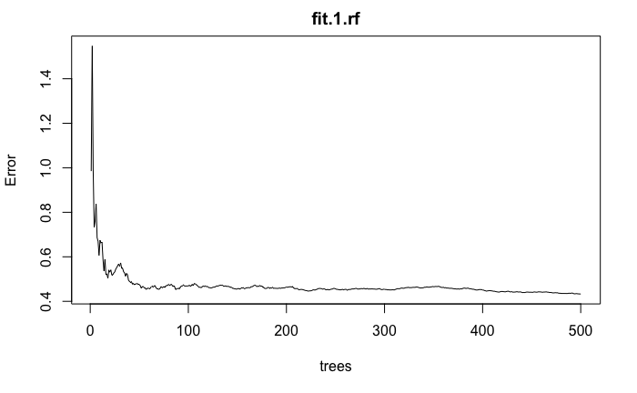

```r
set.seed(1) # for reproducibility, we set the seed
fit.1.rf <- randomForest(VSI~., data.complete, mtry=6, ntree=500)
plot(fit.1.rf)
```

Based on out of bag error, it seems 100 trees is sufficient. Now, let’s tune mtry.

```r
error.p <- 1:150
for (p in 1:150)
{
  rf.temp <- randomForest(VSI~., data.complete, mtry=p, ntree=100)
  error.p[p] <- rf.temp$mse[100]
}
```

[output not shown]

[output cut: 85 more lines]

[output not shown]

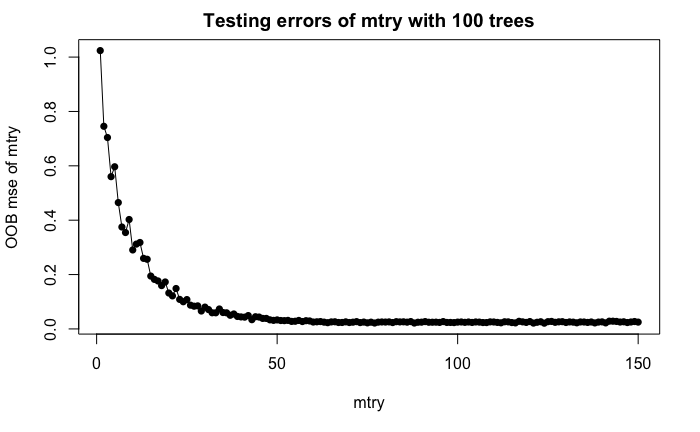

```r
plot(1:150, error.p, pch=16,
     main = "Testing errors of mtry with 100 trees",
     xlab="mtry",
     ylab="OOB mse of mtry")
lines(1:150, error.p)
```

It seems that an mtry between 50 and 70 is appropriate. Accordingly, we will select a final mtry of 60.

Now, let’s develop the final model

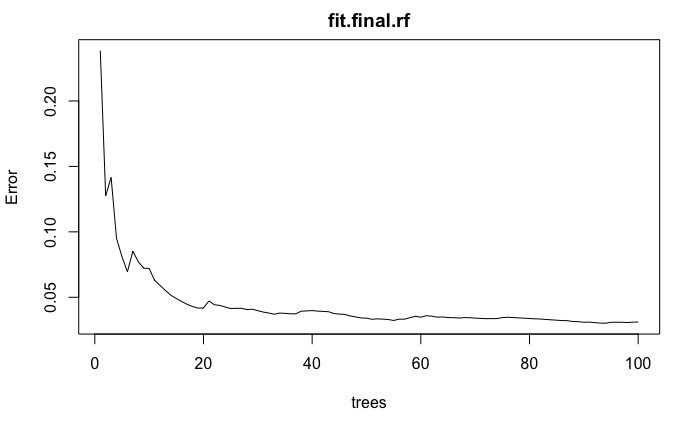

```r
fit.final.rf <- randomForest(VSI~., data.complete, mtry=60, ntree=100)
plot(fit.final.rf)
```